# Course 7 - Regression Models - Week 4 - Notes

## Question 3

If you fit a logistic regression model to a binary variable, for example use of the autolander, then fit a logistic regression model for one minus the outcome (not using the autolander) what happens to the coefficients?

**Answer:**

```r
# We swap the outcome variable
shuttle %>%
    mutate(auto = ifelse(use == 'auto', 0, 1)) %>%
    mutate(wind = fct_relevel(wind, c('tail', 'head'))) %>%
    glm(auto ~ wind, data =., family = 'binomial') ->
    shuttle_logistic

shuttle_logistic %>% summary()
```

```
##
## Call:
## glm(formula = auto ~ wind, family = "binomial", data = .)
##
## Deviance Residuals:
##    Min      1Q  Median      3Q     Max
## -1.073  -1.073  -1.060   1.286   1.300
##
## Coefficients:
##             Estimate Std. Error z value Pr(>|z|)
## (Intercept) -0.28313    0.17855  -1.586    0.113
## windhead     0.03181    0.25224   0.126    0.900
##
## (Dispersion parameter for binomial family taken to be 1)
##
##     Null deviance: 350.36  on 255  degrees of freedom
## Residual deviance: 350.35  on 254  degrees of freedom
## AIC: 354.35
##
## Number of Fisher Scoring iterations: 4
```

We can see the sign has changed. The coefficients are on the log scale, so changing the sign changes the numerator and denominator.

## Question 4

Consider the insect spray data `InsectSprays`. Fit a Poisson model using spray as a factor level. Report the estimated relative rate comapring spray A (numerator) to spray B (denominator).

- **0.9457**
- 0.321
- -0.056
- 0.136

**Answer:**

```r
InsectSprays %>%
    glm(count ~ spray, family = 'poisson', data = .) ->
    insect_pois

( insect_pois %>% coef() -> q4_coef )
```

```
## (Intercept)      sprayB      sprayC      sprayD      sprayE      sprayF
##  2.67414865  0.05588046 -1.94017947 -1.08151786 -1.42138568  0.13926207
```

```r
beta_0 <- q4_coef[1]
beta_1 <- q4_coef[2]
```

The intercept is the log expected count of sprayA. $\beta_1$ is the difference in log expected count, so $\beta_0 + \beta_1$ is the log expected count of sprayB.

So we can do:

```r
exp(beta_0) / exp(beta_0 + beta_1)
```

```
## (Intercept)
##   0.9456522
```

## Question 5

Consider a Poisson glm with an offset, $t$. So, for example, a model of the form `glm(count ~ x + offset(t), family = poisson)`, where `x` is a factor variable comparing a treatment (1) to a control (0) and `t` is the natural log of a monitoring time. What is impact of the coefficient for `x` if we fit the model `glm(count ~ x + offset(t2), family = poisson)` where `t2 <- log(10) + t`? In other words, what happens to the coefficients if we change the units of the offset variable. (Note, adding log(10) on the log scale is multiplying by 10 on the original scale.)

- The coefficient estimate is divided by 10.
- The coefficient is subtracted by log(10).
- **The coefficient estimate is unchanged**
- The coefficient estimate is multiplied by 10.

**Answer:**

The coefficients are unchanged, except the intercept which is shifted by $log(10)$. All of the coefficients are interpretted as log relative rates, so a unit change in the offset would cancel out. However the intercept is not relative but a pure log rate with all the covariates set to 0.

## Question 6

Consider the data:

```r
x <- -5:5
y <- c(5.12, 3.93, 2.67, 1.87, 0.52, 0.08, 0.93, 2.05, 2.54, 3.87, 4.97)
```

Using a knot point at 0, fit a linear model that looks like a hockey stick with two lines meeting at $x = 0$. Include an intercept term, $x$ and the knot point term. What is the estimated slope of the line after 0?

- 2.037
- -0.183
- -1.024
- **1.013**

**Answer:**:

```r
library(lspline)

# Create another variable
tibble(x = x, y = y) %>%
    mutate(z = (x > 0) * x) ->
    q6_data

# Perform a linear regression
( q6_data %>%
    lm(y ~ x + z, data = .) %>%
    coef() ->
    q6_coef )
```

```
## (Intercept)           x           z
##  -0.1825806  -1.0241584   2.0372258
```

```r
# This is from the answer: not sure of this.
q6_coef[2:3] %>% sum()
```

```
## [1] 1.013067
```

```r
# Using the lsplines library
q6_data %>%
    lm(y ~ lspline(x, 0), data = .)
```

```
##
## Call:
## lm(formula = y ~ lspline(x, 0), data = .)
##
## Coefficients:
##    (Intercept)  lspline(x, 0)1  lspline(x, 0)2
##        -0.1826         -1.0242          1.0131
```

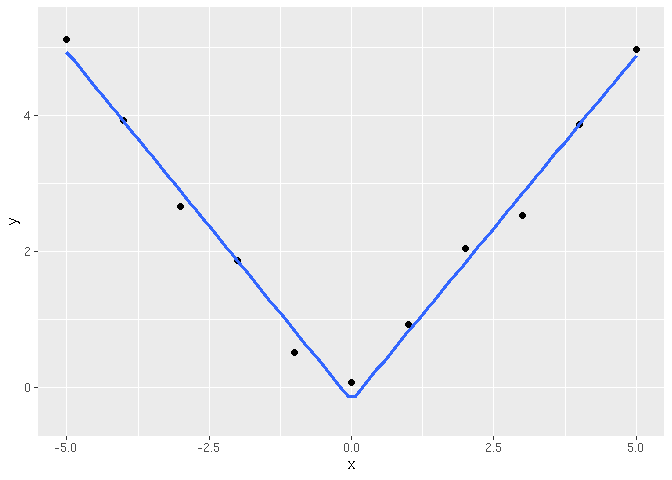

```r
q6_data %>%
    ggplot(aes(x,y)) +
    geom_point() +
    geom_smooth(method = lm, formula = y ~ lspline(x, 0))
```